# Spotify Analysis

### Hypothesis Tests on Audio Features

This is an example of the hypothesis tests which were carried out on each audio feature. Please see hyp_testing.Rmd for full hypothesis testing.

Two sample - independent tests

H0: The mean danceability in 1960s is the same as the mean danceability in 2010s

Ha: The mean danceability in 1960s is less than the mean danceability in 2010s

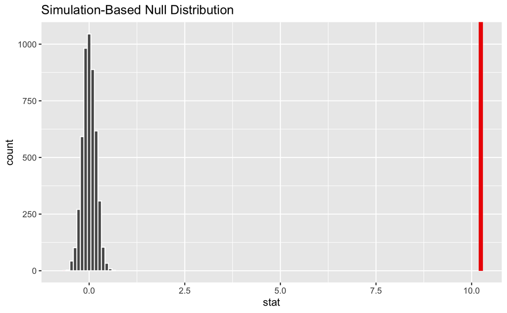

- With a p-value < 0.001 we can reject our null hypothesis in favour for the alternative. So we can say with confidence that the difference in means between 1960 and 2010 is statistically significant.
- This was the case with all of the Audio Features.

## Exploratory Analysis

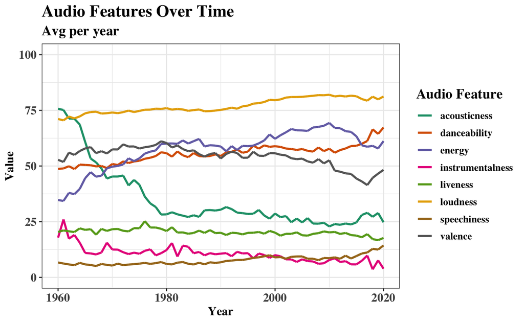

- We can see a gradual rise in Danceability and Loudness, with a massive drop in Acousticness.
- Near the bottom we can see a rise in Speechiness from the 1980s, possibly due the rise in popularity of rap music. And the Instrumentalness decreases over time, showing people are listening significantly less instrumental music than they were in the 1960s.

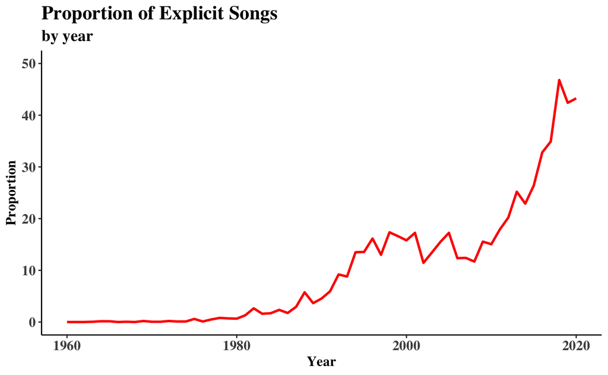

- Here we see a fairly steep rise in the proportion of explicit songs from around 1980. This peaks at almost 50% in 2018.

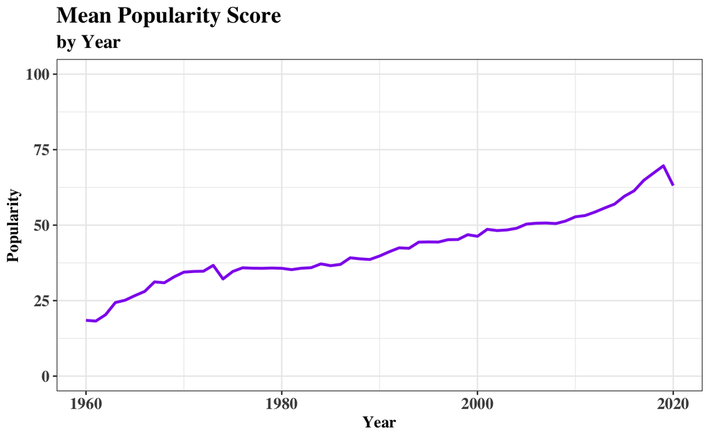

- The gradual rise in the mean popularity score tells us that the Spotify algorithm for calculating the popularity score is affected heavily by how recently the song was released.

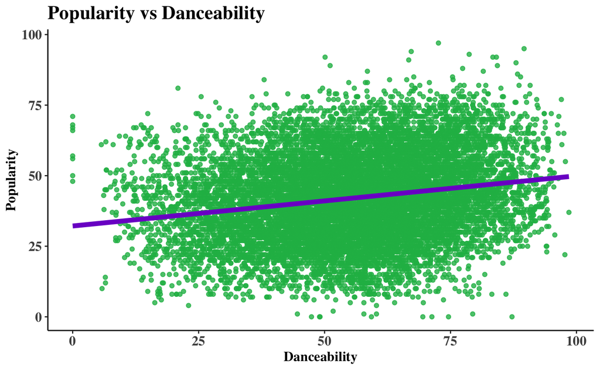

- We’re starting to concentrate a bit more on correlations between Popularity score and our other variables. Here we see a linear relationship between Popularity and Danceability. I used a sample of the data to show this.

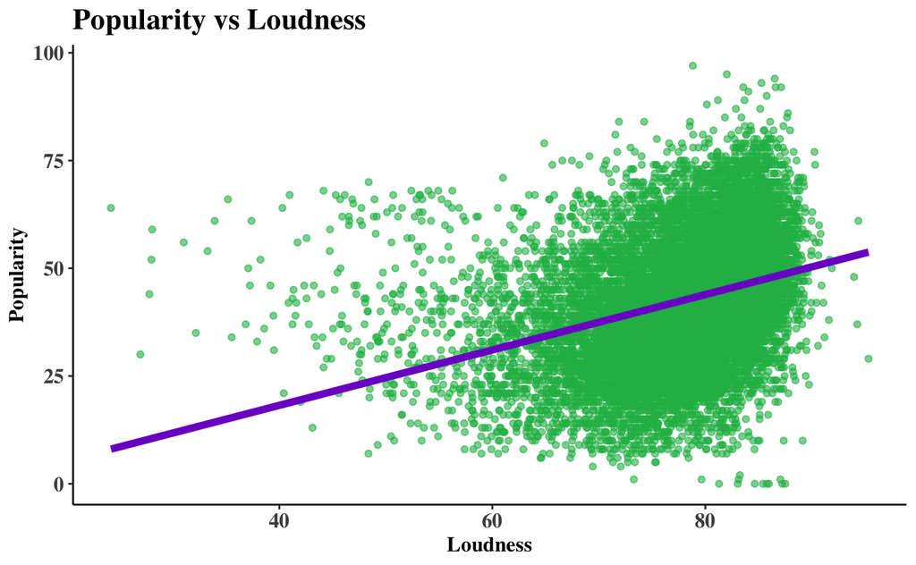

- Again using a sample of the data, we can see another positive linear relationship between Popularity and Loudness. These will help with our explanatory model building.

### Linear Regression Model Build

- To help me answer my question of what makes a song “popular” on spotify, I decided to build an explanatory linear regression model. This type of analysis is used to determine the strength of the relationship between a response variable and multiple explanatory variables.
- popularity = b0 + b1x1 + b2x2 + b3x3….bnxn
- While working on this model building I used a 80-20 Train, Test split method. Meaning I worked on 80% of the data then testing my outcome on the remaning 20%.
- To start this process I plot popularity against each one of my variables or possible explanatory variables and find the strongest correlation.

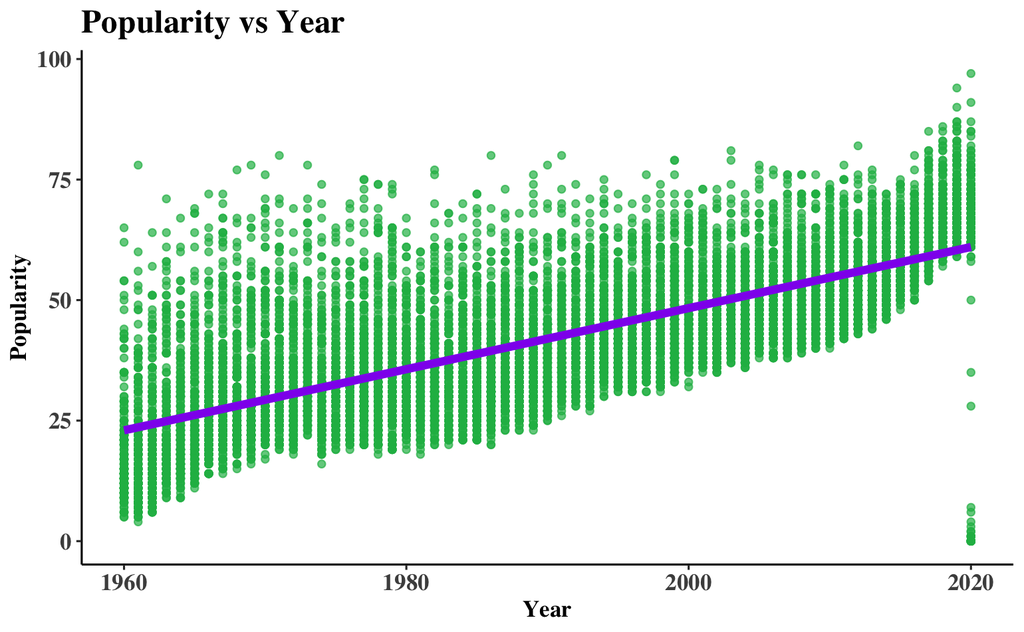

- My strongest correlation was year (the year the track was released) with a correlation of 0.74. I then add this to my model as my first explanatory variable.

```r
model_1a <- lm(popularity ~ year,
               data = train_lm)

summary(model_1a)
```

```
Call:
lm(formula = popularity ~ year, data = train_lm)

Residuals:
    Min      1Q  Median      3Q     Max
-61.186  -7.425  -1.634   5.803  54.459

Coefficients:
                Estimate   Std. Error t value            Pr(>|t|)
(Intercept) -1227.685465     3.759158  -326.6 <0.0000000000000002 ***
year            0.638055     0.001889   337.8 <0.0000000000000002 ***
---
Signif. codes:  0 ‘***’ 0.001 ‘**’ 0.01 ‘*’ 0.05 ‘.’ 0.1 ‘ ’ 1

Residual standard error: 10.36 on 97323 degrees of freedom
Multiple R-squared:  0.5397,    Adjusted R-squared:  0.5396
F-statistic: 1.141e+05 on 1 and 97323 DF,  p-value: < 0.00000000000000022
```

After running my model I’m looking at 3 factors

- The P-value - is this variable making a significant difference. If the P-value is below the significance level of 0.05 then we can reject the null hypothesis and conclude that correlation between the variables is significant
- The R^2 - is a measure that indicates how much of the variation of popularity is explained by the year
- The adjusted R^2 - compensates for the addition of variables. So as we’re building an explanatory model, we don’t want this to drop much lower than the R^2.

#### Anova Test

I used **anova** (Analysis of Variance) tests to check that the difference between my new model and previous models was significant.

```r
anova(model_3a, model_2c)
```

```
Analysis of Variance Table

Model 1: popularity ~ year + danceability + loudness
Model 2: popularity ~ year + danceability
  Res.Df      RSS Df Sum of Sq   F                Pr(>F)
1  97321 10357839
2  97322 10396047 -1    -38208 359 < 0.00000000000000022 ***
---
Signif. codes:  0 ‘***’ 0.001 ‘**’ 0.01 ‘*’ 0.05 ‘.’ 0.1 ‘ ’ 1
```

#### Final Linear Regression Model

```r
model_6a <- lm(popularity ~ year + danceability + loudness + liveness + explicit,
               data = train_lm)

summary(model_6a)
```

```
Call:
lm(formula = popularity ~ year + danceability + loudness + liveness +
    explicit, data = train_lm)

Residuals:
    Min      1Q  Median      3Q     Max
-62.605  -7.357  -1.549   5.814  54.369

Coefficients:
                 Estimate   Std. Error  t value            Pr(>|t|)
(Intercept)  -1177.943939     4.161026 -283.090 <0.0000000000000002 ***
year             0.609366     0.002149  283.497 <0.0000000000000002 ***
danceability     0.029336     0.002043   14.358 <0.0000000000000002 ***
loudness         0.082492     0.004742   17.397 <0.0000000000000002 ***
liveness        -0.036529     0.001864  -19.599 <0.0000000000000002 ***
explicit         1.056643     0.118642    8.906 <0.0000000000000002 ***
---
Signif. codes:  0 ‘***’ 0.001 ‘**’ 0.01 ‘*’ 0.05 ‘.’ 0.1 ‘ ’ 1

Residual standard error: 10.29 on 97319 degrees of freedom
Multiple R-squared:  0.5452,    Adjusted R-squared:  0.5452
F-statistic: 2.334e+04 on 5 and 97319 DF,  p-value: < 0.00000000000000022
```

- So here we have the final model. I stopped adding variables as the Adjusted r^2 started dropping and our multiple r^2 was barely going up.
- All of our P-Values are significant and we have a Multiple R^2 of 0.55, with an adjusted R^2 also of 0.55. This means that 55% of the variance in popularity is explained our other variables.
- This suggests that the model has moderate explanatory power, as about half of the data points can be accounted for by the linear regression line. However, it also tells us that there is a large portion of the variability that remains unexplained and might be attributed to other factors not included in the model.

### Logistic Regression Model Build

- Logistic regression is a statistical analysis method to predict, or explain a binary outcome, such as yes or no, based on prior observations of a data set.
- So rather than using the popularity score I have used the variable I created called is_popular, which splits the data in to a logical type, so it’s TRUE if the song has a popularity score of 50 and above.
- The way this is built is very similar to the linear model. I look for correlations, and I add them to my model 1 at a time, check they are significant. The main difference is that I’m looking for for a high AUC score this time, rather than the multiple R^2 I was looking for in the linear model.
- I decided to no longer include the year or decade the song was released for this model. It had such a large influence on the linear model I thought it would be more interesting to see how the logistic model fared without it. Also, if we’re building a model to assist with the writing of a current day “popular” song, then including variables such as year and decade are of no help.

#### Final Logistic Regression Model

```r
model_4_final <- glm(is_popular ~ loudness + explicit + danceability + no_of_artists,
             family = "binomial",
             data = train_log_mod)

summary(model_4_final)
```

```
Call:
glm(formula = is_popular ~ loudness + explicit + danceability +
    no_of_artists, family = "binomial", data = train_log_mod)

Deviance Residuals:
    Min       1Q   Median       3Q      Max
-2.2485  -0.8587  -0.6649   1.1489   3.7147

Coefficients:
                Estimate Std. Error z value            Pr(>|z|)
(Intercept)   -7.7509780  0.0992559  -78.09 <0.0000000000000002 ***
loudness       0.0781670  0.0012220   63.97 <0.0000000000000002 ***
explicit       1.0105258  0.0237873   42.48 <0.0000000000000002 ***
danceability   0.0097052  0.0004544   21.36 <0.0000000000000002 ***
no_of_artists  0.1760127  0.0113852   15.46 <0.0000000000000002 ***
---
Signif. codes:  0 ‘***’ 0.001 ‘**’ 0.01 ‘*’ 0.05 ‘.’ 0.1 ‘ ’ 1

(Dispersion parameter for binomial family taken to be 1)

    Null deviance: 121334  on 97324  degrees of freedom
Residual deviance: 110599  on 97320  degrees of freedom
AIC: 110609

Number of Fisher Scoring iterations: 4
```

```
Area under the curve: 0.7208
```

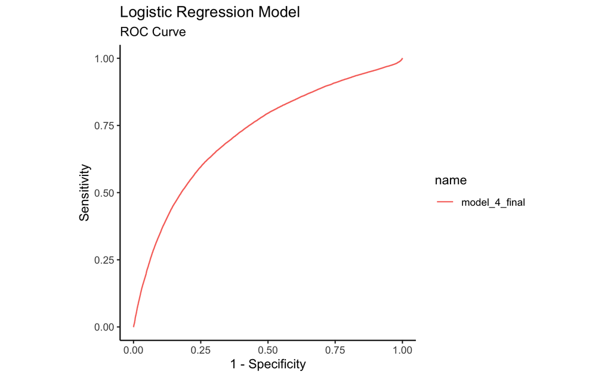

```r
log_mod_1990 <- train_log_mod %>%
  filter(decade == 1990 |
           decade == 2000 |
           decade == 2010)

model_90_00_10 <- glm(is_popular ~ loudness + explicit + danceability + no_of_artists,
                      family = "binomial",
                      data = log_mod_1990)

summary(model_90_00_10)

tidy(model_90_00_10)

train_model_90_00_10 <- log_mod_1990 %>%
  add_predictions(model_90_00_10, type = "response")

roc_obj_mod_90_00_10 <- train_model_90_00_10 %>%
  roc(response = is_popular, predictor = pred)


roc_curve <- ggroc(
  data = list(
    best_model = roc_obj_mod4,
    dec_60s_70s_80s = roc_obj_mod_60_70_80,
    dec_90s_00s_10s = roc_obj_mod_90_00_10
  ),
  legacy.axes = TRUE,
  linewidth = 2) +
  coord_fixed() +
  labs(x = "1 - Specificity",
       y = "Sensitivity") +
  scale_colour_brewer(palette =  "Dark2") +
  scale_colour_discrete(labels = c("Final Model", "60s, 70s & 80s", "90s, 00s & 10s")) +
  theme_classic() +
  theme(axis.text  = element_text(face = "bold", size = 18, family = "Times"),
        axis.title  = element_text(face = "bold", size = 18, family = "Times"),
        title = element_text(face = "bold", size = 18, family = "Times"),
        legend.text = element_text(face = "bold", size = 18, family = "Times"),
        #legend.text = element_blank(),
        legend.title = element_blank()
        #legend.key = element_blank()
  )

auc(roc_obj_mod_90_00_10)

roc_curve

ggsave("plot_images/log_models.png", dpi = 720, width = 12, height = 6)
```

[output not shown]

```r
log_mod_1990 <- train_log_mod %>%
  filter(decade == 1990 |
           decade == 2000 |
           decade == 2010)

model_90_00_10 <- glm(is_popular ~ loudness + explicit + danceability + no_of_artists,
                      family = "binomial",
                      data = log_mod_1990)

summary(model_90_00_10)

tidy(model_90_00_10)

train_model_90_00_10 <- log_mod_1990 %>%
  add_predictions(model_90_00_10, type = "response")

roc_obj_mod_90_00_10 <- train_model_90_00_10 %>%
  roc(response = is_popular, predictor = pred)


roc_curve <- ggroc(
  data = list(
    best_model = roc_obj_mod4
  ),
  legacy.axes = TRUE,
  linewidth = 2) +
  coord_fixed() +
  labs(x = "1 - Specificity",
       y = "Sensitivity") +
  scale_colour_brewer(palette =  "Dark2") +
  scale_colour_discrete(labels = "Final Model") +
  theme_classic() +
  theme(axis.text  = element_text(face = "bold", size = 18, family = "Times"),
        axis.title  = element_text(face = "bold", size = 18, family = "Times"),
        title = element_text(face = "bold", size = 18, family = "Times"),
        legend.text = element_text(face = "bold", size = 16, family = "Times"),
        legend.title = element_blank()
  )

auc(roc_obj_mod_90_00_10)

roc_curve

ggsave("plot_images/log_best_model.png", dpi = 720, width = 12, height = 6)
```

[output not shown]